# 'Systems all the way down': Managing Complexity with BondGraphTools

```
Dr. Peter Cudmore.
Systems Biology Labratory,
The School of Chemical and Biomedical Engineering,
The University of Melbourne.
```

[figure not shown]

## *We want to predict and control complex energetic systems!*

For our purposes a dynamic system is *complex* when:

- It is made up of many moving parts, or subsystems (High Dimensional).
- The subsystems are not all of the same type (Heterogenenous).
- The subsystems are complicated (Nonlinear and/or Noisy).
- There are well defined boundaries between the subsystems (Network Topology).

By *energetic system*, we mean that *energy* is the quantity that is exchanged between subsystems.

> There is a fact, or if you wish, a law, governing all natural phenomena that are known to date. There is no known exception to this law—it is exact so far as we know. The law is called the conservation of energy.

- R. Feynman, 1963. [7]

## *We want to predict and control complex energetic systems!*

For complex systems, how can we:

- Navigate between different spatio-temportal scales in a systematic manner.
- Talk about qualitiative properties such as existence, stability and bifucations of solutions.
- Estimate paramaters and states from limited, noisy datasets so as to make predicitons.
- Design, evaluate and optimise control schemes.
- Understand how complex physical systems *compute*.

## How do we *scale up* nonlinear dynamics?

*Especially when differential equation models can quickly become as complex as the system in question!*

## The recipe:

- Port-based modelling: 'Energy' distributed across network toplogy.
- Object-oriented framework: model composition, encapsulation and inheritance.
- Modern scripting engine: automation, data integration.
- Analysis tools: DAE solvers, numerical continuation, etc.

```python
import BondGraphTools
```

## `BondGraphTools`

`BondGraphTools` (https://github.com/BondGraphTools) a framework for modelling energetic systems.

- Based upon the bond graph and port-Hamiltonian modelling.
- Provies a *minimal* object-oriented interface for constructing, composiong and simulating models.
- Implemented in `python` using the `scipy` stack.
- Computational 'grunt' is provided via `julia` and `DifferentialEquations.jl`.

'Bond Graphs' are a multi-domain port-based graphical modelling technique used predominatly in mechantronics.  
Port-Hamiltonian systems integrate geometric approaches from classical mechanics and control theory with port based modelling.

Both are concerned with the *energetic systems*.

## Definition (Energetic System)

An energetic system is a tuple $(M, \mathcal{D}, U,\Phi)$ where the

- *state space* $M$ is a differentiable manifold of $\dim(M) = m\ge 0$ with tangent bundle $TM$.
- *port space* $\mathcal{D} \subset \mathcal{E} \times \mathcal{F}$ is a *Dirac structure* where $\mathcal{F}$ is a linear space, $\mathcal{E} = \mathcal{F}^*$ and $\dim{\mathcal{D}} = \dim{\mathcal{F}}= n \ge 0$.
- *control space* $U \subset C^r:\mathbb{R}_+ \rightarrow \mathbb{R^k}$ with $k\ge 0$ are sufficiently differentiable control functions.
- *consitutive relation* is a smooth map $\Phi: TM \times \mathcal{D} \times U\times\mathbb{R}_+ \rightarrow \mathbb{R}^{m+n}$ with $m+n >0$ such that the system dynamics satisfy the differential-algebraic equations $$\Phi(x',x,e,f,u,t)=0.$$

The incoming *power* (instantaenous rate of energy change, positive corresponding to inwards by convention) is given by $P_\text{in} = \left<e,f\right>$ for $(e,f)\in \mathcal{D}$

## Composition, Encapsulation

[figure not shown]

## Corollary (Composition) [8]

If $\Phi_1,\Phi_2$ are energetic systems, then $\Phi_0 = (\Phi_1,\Phi_2)$ is also an energetic system.

For two ports $i,j$ are connected; then $P_i + P_j = 0$. By convetion we take this to mean that $$e_i - e_j =0\qquad f_i+f_j=0$$

This allows for *heirarchical model building* and hence *computational modularity* even when the system is highly interconnected.

## Modern Scripting Language

[figure not shown]

```python
from BondGraphTools import new, add, connect, expose

def make_rl_model():
    phi_0 = new(name="Model")
    phi_1 = new("1") # Conservation Law.
    phi_2 = new("R", value=0.3) # Dissipation.
    phi_3 = new("I", value=1) # Storage.
    port = new("SS") # Internal Port

    add(phi_0, phi_1, phi_2, phi_3, port)

    expose(port)

    connect(port, phi_1)
    connect(phi_1, phi_2)
    connect(phi_1, phi_3)
    return phi_0

model = make_rl_model()
model.constitutive_relations
```

$$\left [ dx_{0} - e_{0} + \frac{3 x_{0}}{10}, \quad f_{0} - x_{0}\right ]$$

## Python + SciPy( sympy, numpy, matplotlib)

```python
phi_4 = new("C", value=1)
phi_4._constitutive_relations = [
    'q_0 + q_0^3 - C * e_0', 'dq_0 - f_0'
]


add(phi_0, phi_4)
connect(phi_4, phi_1)
phi_0.constitutive_relations
```

$$\left [ dx_{0} + x_{1}, \quad dx_{1} + e_{0} - x_{0}^{3} - x_{0} + \frac{3 x_{1}}{10}, \quad f_{0} + x_{1}\right ]$$

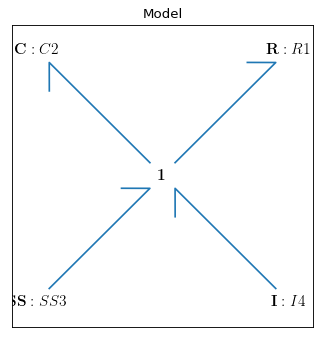

```python
from BondGraphTools import draw
draw(phi_0)
plt.gcf().set_size_inches(5,5) #matplotlib
```

## Analysis Tools

Example; simulate with a driving force of $u(t) = 8\sin(0.3t)$

```python
from BondGraphTools import simulate

simulation_model = new()
source = new("Se")
add(simulation_model, source, phi_0)
connect(source, phi_0)

t,x = simulate(simulation_model,
               x0=[0, 1],
               timespan=[0,40],
               control_vars=["8*sin(0.3*t)"])
```

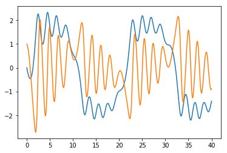

```python
from matplotlib.pyplot import plot
_ = plot(t,x)
```